# Lectures 28 and 29: The Francis QR algorithm

## Simultaneous iteration

If we perform power iteration simultaneously on independent vectors, and $A$ has eigenvalues of distinct magnitudes, then the content of each vector is dominated by the eigenvectors sorted in order. QR factorization thus reveals these eigenvectors in order, and we can approximately diagonalize $A$ as the iteration continues.

```matlab
A = magic(6)
```

```
A =

    35     1     6    26    19    24
     3    32     7    21    23    25
    31     9     2    22    27    20
     8    28    33    17    10    15
    30     5    34    12    14    16
     4    36    29    13    18    11
```

We symmetrize the matrix and find a similar tridiagonal substitute.

```matlab
A = hess(A+A');
lambda = eig(A);
[~,idx] = sort(abs(lambda));
lambda = lambda(idx)
```

```
lambda =

    5.8213
    8.8418
  -21.0276
  -69.2592
   75.6237
  222.0000
```

We'll track progress by means of the sizes of the subdiagonal elements.

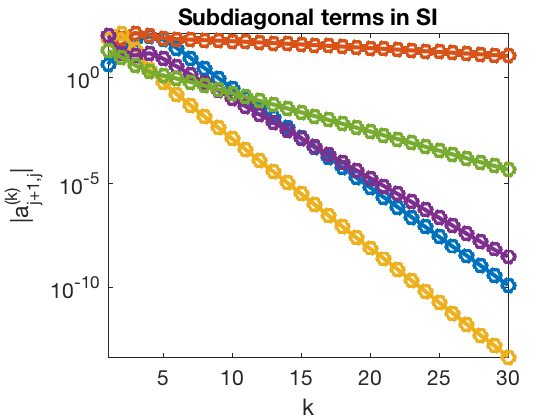

```matlab
Q = eye(6);
subdiag = [];
for k = 1:30
    Z = A*Q;
    [Q,R] = qr(Z);  % Q converges to eigenvectors
    D = Q'*A*Q;     % D converges to diagonal
    subdiag = [subdiag; diag(D,-1)'];
end
semilogy(abs(subdiag),'-o')
axis tight
title('Subdiagonal terms in SI')
xlabel('k'), ylabel('|a^{(k)}_{j+1,j}|')
```

The graph confirms that we are converging to all the eigenvalues linearly.

## Unshifted QR iteration

The unshifted QR iteration is algebraically equivalent to SI.

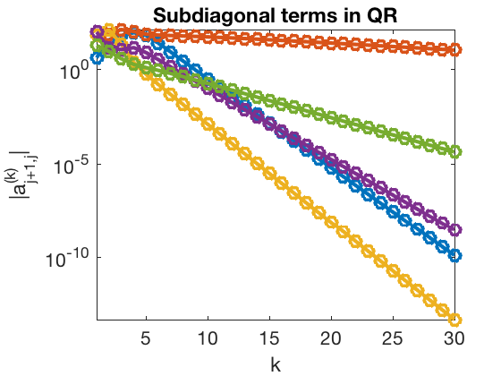

```matlab
D = A;
subdiag = [];
for k = 1:30
    [Q,R] = qr(D);
    D = R*Q;
    subdiag = [subdiag; diag(D,-1)'];
end
semilogy(abs(subdiag),'-o')
axis tight
title('Subdiagonal terms in QR')
xlabel('k'), ylabel('|a^{(k)}_{j+1,j}|')
```

## Shifted QR iteration

As stated above, the SI/QR iteration finds eigenvalues in order sorted by magnitude.

```matlab
D
```

```
D =

  222.0000   -0.0000    0.0000    0.0000    0.0000    0.0000
   -0.0000   74.8884  -10.2952   -0.0000    0.0000    0.0000
         0  -10.2952  -68.5239    0.0000   -0.0000    0.0000
         0         0    0.0000  -21.0276   -0.0000    0.0000
         0         0         0   -0.0000    8.8418   -0.0000
         0         0         0         0   -0.0000    5.8213
```

This fact is exploited by using the lower right element in a shift-and-invert strategy.

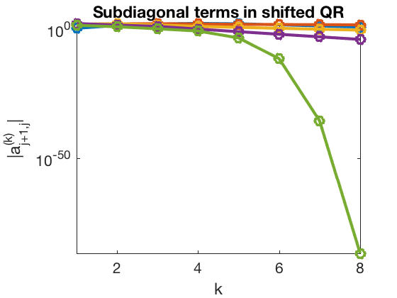

```matlab
D = A;  m = length(A);
subdiag = [];
for k = 1:8
    mu = D(m,m);
    [Q,R] = qr(D - mu*eye(m));
    D = R*Q + mu*eye(m);
    subdiag = [subdiag; diag(D,-1)'];
end
semilogy(abs(subdiag),'-o')
axis tight
title('Subdiagonal terms in shifted QR')
xlabel('k'), ylabel('|a^{(k)}_{j+1,j}|')
```

We're seeing cubic convergence for one eigenvalue. (The values are impossibly small because we haven't maintained true symmetry, thereby dodging the effects of roundoff.)

```matlab
format short e
D
```

```
D =

   2.2192e+02   4.7716e+00   4.1744e-14  -3.6054e-14  -1.9004e-14   2.2813e-14
   4.7716e+00  -6.0339e+01   3.4682e+01   7.6050e-15  -5.0902e-15  -1.7010e-14
            0   3.4682e+01   6.6786e+01  -3.0881e-01   7.1400e-15   2.4087e-14
            0            0  -3.0881e-01  -2.1027e+01   8.1187e-05   1.4624e-14
            0            0            0   8.1187e-05   5.8213e+00   1.2373e-15
            0            0            0            0  -9.5164e-88   8.8418e+00
```

As discussed in the text, the simple corner shift isn't quite general enough. Instead one uses a *Wilkinson shift* as described there.

## Deflation

Once an eigenvalue is found in the lower right corner, the eigenvalue problem for the upper left submatrix can be decoupled, leading to the recursive technique of *deflation*. Note that the subdiagonal is already substantially reduced, so the remaining eigenvalues tend to be found quickly.

```matlab
D = D(1:m-1,1:m-1);  m = m-1;
mu = D(m,m);
[Q,R] = qr(D - mu*eye(m));
D = R*Q + mu*eye(m)
```

```
D =

   2.2199e+02  -1.6508e+00   1.1573e-15  -3.5874e-14   1.9111e-14
  -1.6508e+00  -6.1546e+01  -3.2509e+01   5.4401e-15   7.4483e-15
            0  -3.2509e+01   6.7920e+01   1.1829e-01  -4.1038e-15
            0            0   1.1829e-01  -2.1027e+01  -1.2008e-14
            0            0            0   7.4234e-16   5.8213e+00
```